# The `ChainLadder` Package

## Acknowledgments

- Original presentation adapted from content found at http://opensourcesoftware.casact.org/chain-ladder
- Thanks to Brian for his slides from 2019
- Thanks to Dan Murphy for his slides from 2018

## Package

Make sure you have the `ChainLadder` package installed.

```r
install.packages('ChainLadder')
library(ChainLadder)
library(tidyverse)
```

## Introduction

A package developed by Markus Gesmann, an actuary formerly at Lloyd’s, with several contributors. From the description file:

> Various statistical methods and models which are typically used for the estimation of outstanding claims reserves in general insurance, including those to estimate the claims development result as required under Solvency II.

## Load some data

Load Sch P data from http://www.casact.org/research/index.cfm?fa=loss_reserves_data

```r
asl17g <- read.csv('http://www.casact.org/research/reserve_data/othliab_pos.csv')
names(asl17g)
```

```
##  [1] "GRCODE"             "GRNAME"             "AccidentYear"
##  [4] "DevelopmentYear"    "DevelopmentLag"     "IncurLoss_h1"
##  [7] "CumPaidLoss_h1"     "BulkLoss_h1"        "EarnedPremDIR_h1"
## [10] "EarnedPremCeded_h1" "EarnedPremNet_h1"   "Single"
## [13] "PostedReserve97_h1"
```

## Fields in asl17g

| Field | Description |
| --- | --- |
| GRCODE | NAIC company code (including insurer groups and single insurers) |
| GRNAME | NAIC company name (including insurer groups and single insurers) |
| AccidentYear | Accident year(1988 to 1997) |
| DevelopmentYear | Development year (1988 to 1997) |
| DevelopmentLag | Development year (AY-1987 + DY-1987 - 1) |
| IncurLoss_h1 | Incurred losses and allocated expenses reported at year end |
| CumPaidLoss_h1 | Cumulative paid losses and allocated expenses at year end |
| BulkLoss_h1 | Bulk and IBNR reserves on net losses and defense and cost containment expenses reported at year end |
| PostedReserve97_h1 | Posted reserves in year 1997 taken from the Underwriting and Investment Exhibit - Part 2A, including net losses unpaid and unpaid loss adjustment expenses |
| EarnedPremDIR_h1 | Premiums earned at incurral year - direct and assumed |
| EarnedPremCeded_h1 | Premiums earned at incurral year - ceded |
| EarnedPremNet_h1 | Premiums earned at incurral year - net |
| Single | 1 indicates a single entity, 0 indicates a group insurer |

## Recap

Take a moment to invesitgate the data yourself. Some suggestions…

```r
# What GROUPs are here?
sort(unique(asl17g$GRNAME))
```

- How many groups are there?
- What is a unique key on the data? How can one prove it?
- How would you calculate the total premium for ASL 17 by accident year?

## Answer: how many groups?

```r
length(unique(asl17g$GRNAME))
```

```
## [1] 236
```

```r
asl17g$GRNAME %>% unique %>% length
```

```
## [1] 236
```

```r
asl17g %>%
  group_by(GRNAME) %>%
  summarize() %>%
  nrow
```

```
## [1] 236
```

## Answer: unique key

```r
nrow(asl17g)
```

```
## [1] 23900
```

```r
nrow(unique(asl17g[, c('GRCODE', 'AccidentYear', 'DevelopmentYear')]))
```

```
## [1] 23900
```

```r
nrow(unique(asl17g[, c('GRCODE', 'AccidentYear', 'DevelopmentLag')]))
```

```
## [1] 23900
```

```r
nrow(unique(asl17g[, c('GRCODE', 'AccidentYear')]))
```

```
## [1] 2390
```

```r
nrow(unique(asl17g[, c('GRCODE', 'DevelopmentLag')]))
```

```
## [1] 2390
```

```r
nrow(unique(asl17g[, c('AccidentYear', 'DevelopmentLag')]))
```

```
## [1] 100
```

## Answer: premium by accident year?

```r
asl17g %>%
  dplyr::filter(DevelopmentYear == 1997) %>%
  group_by(AccidentYear) %>%
  summarize(TotalPremium = sum(EarnedPremDIR_h1))
```

```
## # A tibble: 10 x 2
##    AccidentYear TotalPremium
##           <int>        <int>
##  1         1988       699282
##  2         1989       739075
##  3         1990       784273
##  4         1991       833930
##  5         1992       868809
##  6         1993       950941
##  7         1994      1055864
##  8         1995      1173617
##  9         1996      1233446
## 10         1997      1246770
```

## Clean up the data

Aggregate and clean up the data a little.

```r
asl17 <- asl17g %>%
  rename(
    AY = AccidentYear,
    DY = DevelopmentYear,
    Dev = DevelopmentLag) %>%
  group_by(AY, DY, Dev) %>%
  summarize(
    UltLoss = sum(IncurLoss_h1),
    PdLoss = sum(CumPaidLoss_h1),
    IBNR = sum(BulkLoss_h1),
    GPE = sum(EarnedPremDIR_h1)) %>%
  ungroup() %>%
  mutate(
    IncLoss = UltLoss - IBNR)
```

## `as.triangle`

- `origin` is the row names of the triangle
- `dev` is the column names of the triangle

```r
tri.inc <- as.triangle(
  asl17[asl17$DY <= 1997, ],
  origin = 'AY',
  dev = 'Dev',
  value = 'IncLoss')

tri.pd <- as.triangle(
  asl17[asl17$DY <= 1997, ],
  origin = 'AY',
  dev = 'Dev',
  value = 'PdLoss')

tri.gpe <- as.triangle(
  asl17[asl17$DY <= 1997, ],
  origin = 'AY',
  dev = 'Dev',
  value = 'GPE')

tri.os <- tri.inc - tri.pd
```

## Investigate results

```r
tri.pd
```

```
##       Dev
## AY         1      2      3      4      5      6      7      8      9     10
##   1988 31447  87470 146807 220502 256564 282111 300903 308636 314566 317889
##   1989 36601  99778 178262 238864 289540 318666 331488 343442 350684     NA
##   1990 41035 108655 190403 262674 302957 334770 352726 361103     NA     NA
##   1991 39031 126807 227783 316632 368941 402043 426085     NA     NA     NA
##   1992 42801 126926 222655 304301 350992 389250     NA     NA     NA     NA
##   1993 44930 173066 293039 378512 434995     NA     NA     NA     NA     NA
##   1994 54253 169202 296394 402244     NA     NA     NA     NA     NA     NA
##   1995 39780 167908 294332     NA     NA     NA     NA     NA     NA     NA
##   1996 62630 191258     NA     NA     NA     NA     NA     NA     NA     NA
##   1997 54130     NA     NA     NA     NA     NA     NA     NA     NA     NA
```

Etc.

## How could you use `dplyr`?

```r
asl17 %>%
  dplyr::filter(DY <= 1997) %>%
  select(AY, Dev, PdLoss) %>%
  tidyr::spread(key = Dev, value = PdLoss)
```

```
## # A tibble: 10 x 11
##       AY   `1`    `2`    `3`    `4`    `5`    `6`    `7`    `8`    `9`   `10`
##    <int> <int>  <int>  <int>  <int>  <int>  <int>  <int>  <int>  <int>  <int>
##  1  1988 31447  87470 146807 220502 256564 282111 300903 308636 314566 317889
##  2  1989 36601  99778 178262 238864 289540 318666 331488 343442 350684     NA
##  3  1990 41035 108655 190403 262674 302957 334770 352726 361103     NA     NA
##  4  1991 39031 126807 227783 316632 368941 402043 426085     NA     NA     NA
##  5  1992 42801 126926 222655 304301 350992 389250     NA     NA     NA     NA
##  6  1993 44930 173066 293039 378512 434995     NA     NA     NA     NA     NA
##  7  1994 54253 169202 296394 402244     NA     NA     NA     NA     NA     NA
##  8  1995 39780 167908 294332     NA     NA     NA     NA     NA     NA     NA
##  9  1996 62630 191258     NA     NA     NA     NA     NA     NA     NA     NA
## 10  1997 54130     NA     NA     NA     NA     NA     NA     NA     NA     NA
```

## Mack Chain Ladder

- Uses “chain ladder” methods
- Predicts ultimates and standard errors
- Several parameters to customize analysis
- Standard error method: http://www.actuaries.org/LIBRARY/ASTIN/vol29no2/361.pdf

```r
MackChainLadder <- function (
  Triangle,
  weights = 1,
  alpha = 1,
  est.sigma = "log-linear",
  tail = FALSE,
  tail.se = NULL,
  tail.sigma = NULL,
  mse.method = "Mack") {...}
```

## Parameters

[output not shown]

## Default example

```r
mcl <- MackChainLadder(tri.inc)
print(mcl)
## MackChainLadder(Triangle = tri.inc)
##
##       Latest Dev.To.Date Ultimate    IBNR Mack.S.E CV(IBNR)
## 1988 319,559       1.000  319,559       0        0      NaN
## 1989 353,245       0.999  353,714     469    1,839    3.918
## 1990 372,163       0.987  376,891   4,728    3,400    0.719
## 1991 460,713       0.982  469,139   8,426    4,862    0.577
## 1992 451,221       0.958  470,878  19,657    7,850    0.399
## 1993 504,667       0.922  547,386  42,719   12,602    0.295
## 1994 581,599       0.865  672,339  90,740   21,880    0.241
## 1995 444,272       0.758  586,159 141,887   28,372    0.200
## 1996 378,987       0.590  642,261 263,274   42,193    0.160
## 1997 220,509       0.356  619,232 398,723   58,959    0.148
##
##                 Totals
## Latest:   4,086,935.00
## Dev:              0.81
## Ultimate: 5,057,557.97
## IBNR:       970,622.97
## Mack.S.E     98,436.45
## CV(IBNR):         0.10
```

Try `tri.pd` and `tri.gpe` yourself.

## Diagnotic plots with `plot`

Plots six different graphs

1. Mack Chain Ladder Results
2. Chain ladder developments by origin period
3. Standardised residuals by Fitted value
4. Standardised residuals by Origin Period
5. Standardised residuals by Calendar period
6. Standardised residuals by Development period

The residual plots should be scattered with no pattern or direction for Mack’s method of calculating the standard error to apply. Patterns could be a result of a trend that should be investigated further. For more information see http://www.casact.org/pubs/proceed/proceed00/00245.pdf.

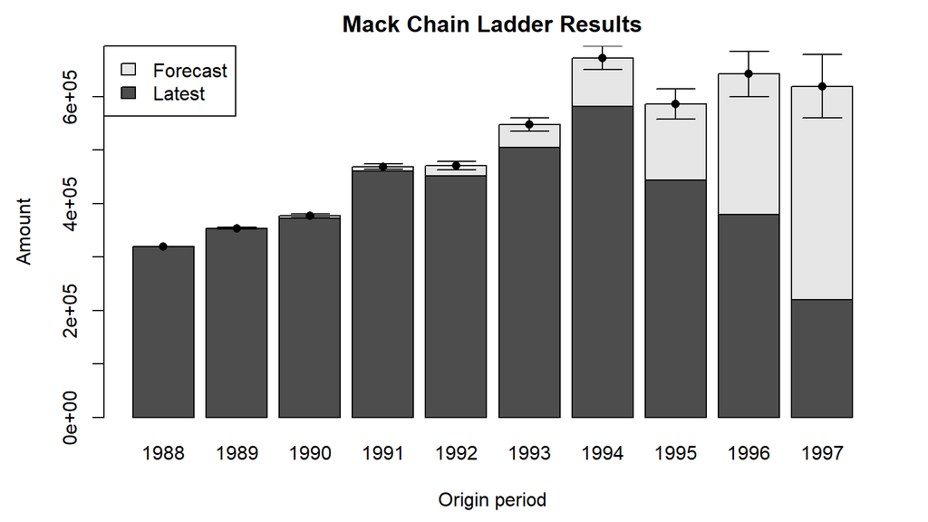

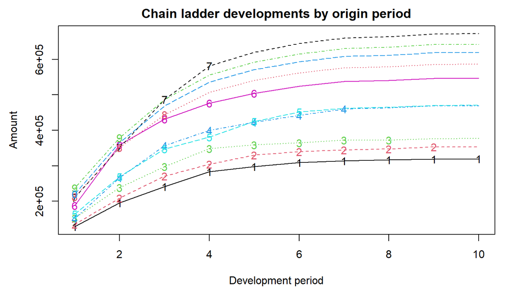

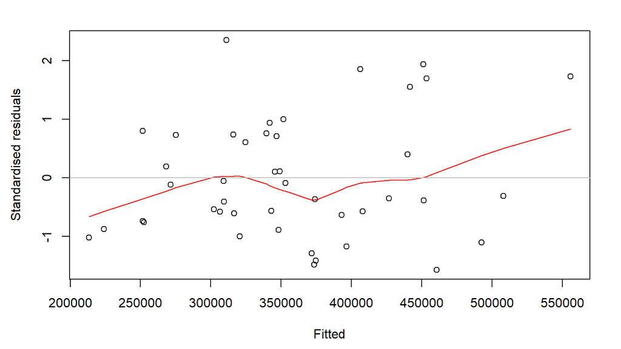

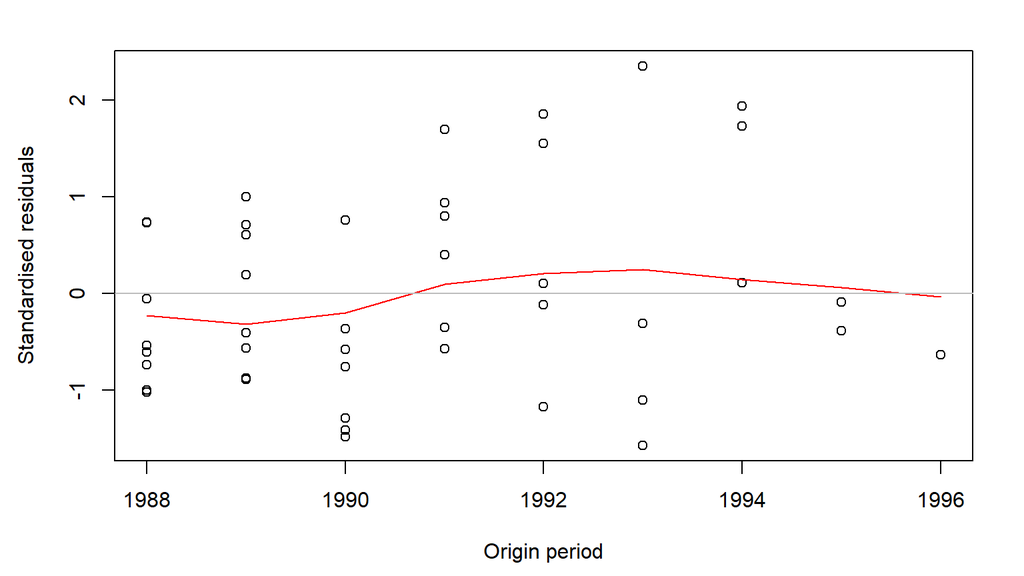

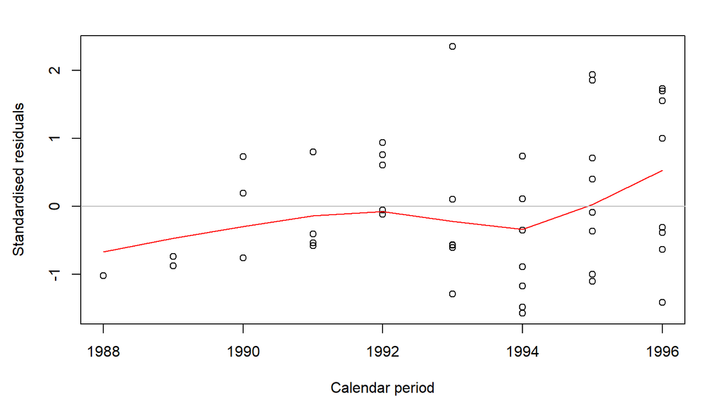

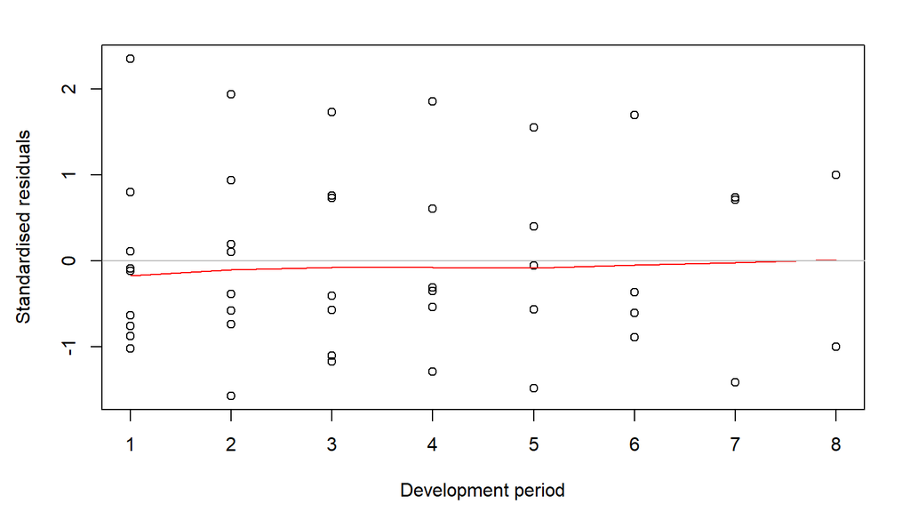

## Plot a triangle

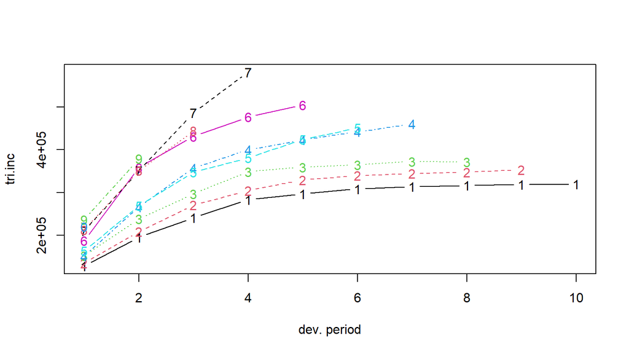

```r
plot(tri.inc)
```

## What’s the return value?

| Object | Description |
| --- | --- |
| `call` | the original function call, e.g. `MackChainLadder(tri.inc, weights = w, tail = 1.1)` |
| `triangle` | triangle data passed in |
| `FullTriangle` | forecasted full triangle |
| `weights` | triangle of weights |
| `Models` | linear regression models for each development period |
| `f` | chain-ladder age-to-age factors |
| `tail` | tail factor used. If tail was set to TRUE the output will include the linear model used to estimate the tail factor |
| *error-related fields* | *see Mack’s original paper* |

## Method `alpha = 0`

```r
# Simple average of the dev ratios
mcl0 <- MackChainLadder(tri.inc, alpha = 0)
```

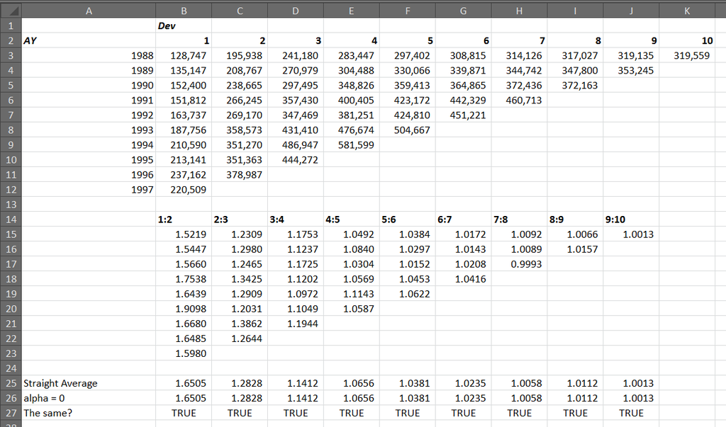

## Method `alpha = 1`

```r
# Chain Ladder ratio ("loss wtd average")
mcl1 <- MackChainLadder(tri.inc, alpha = 1)
```

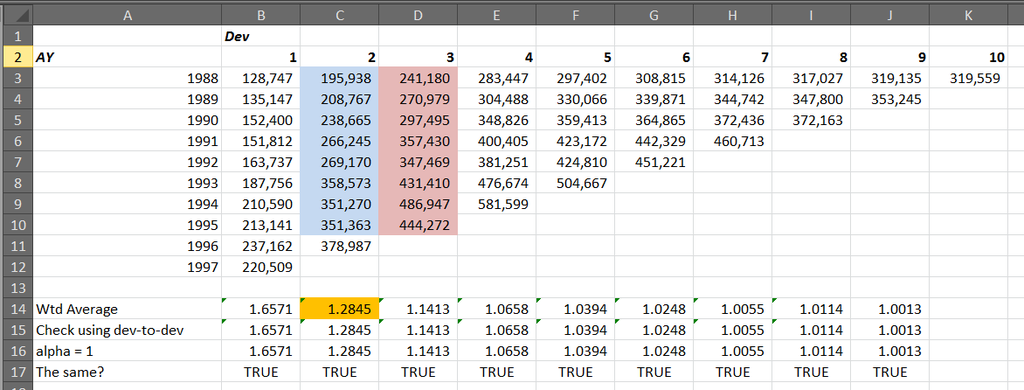

## Method `alpha = 2`

```r
# Same as `lm` with no intercept
mcl2 <- MackChainLadder(tri.inc, alpha = 2)
```

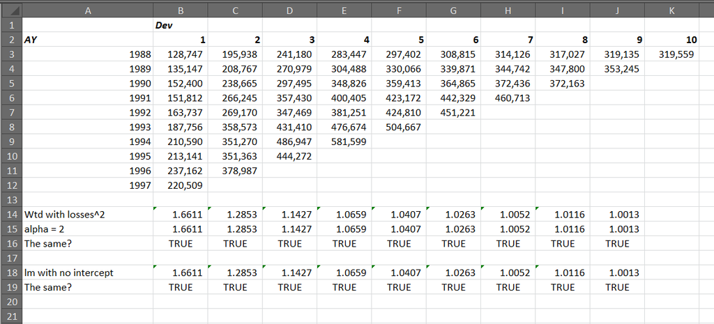

## Using `lm`

```r
x <- tri.inc[, 1:9]
y <- tri.inc[, 2:10]
x[is.na(x)] <- 0
y[is.na(y)] <- 0

beta0 <- numeric()
beta1 <- numeric()
for (i in 1:8) {
  beta0[i] <- lm(
    y[1:(10-i), i] ~ 0 + x[1:(10-i), i])$coefficient[1]

  beta1[i] <- lm(
    y[1:(10-i), i] ~ 1 + x[1:(10-i), i])$coefficient[2]
}

print(beta0)
```

```
## [1] 1.661057 1.285341 1.142698 1.065855 1.040688 1.026294 1.005232 1.011568
```

```r
print(beta1)
```

```
## [1] 1.7561770 1.3034302 1.1681879 1.0676096 1.1102467 1.1062104 0.9466107
## [8] 1.1084392
```

## Compare with Excel

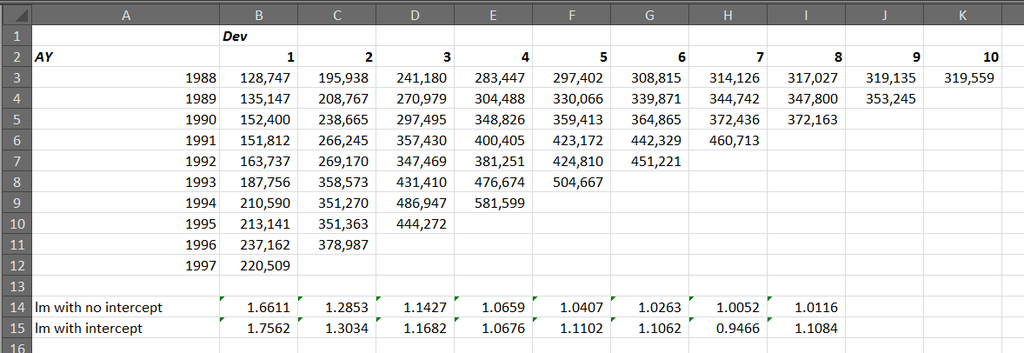

## Different Tails

```r
MackChainLadder(tri.inc)$tail
```

```
## [1] FALSE
```

```r
MackChainLadder(tri.inc, tail = 1.1)$tail
```

```
## [1] 1.1
```

```r
MackChainLadder(tri.inc, tail = TRUE)$tail
```

```
## $tail.factor
## [1] 1.002256
##
## $tail.model
##
## Call:
## lm(formula = log(f - 1) ~ fn)
##
## Coefficients:
## (Intercept)           fn
##      0.2073      -0.6990
```

## Use weights to remove points from development

```r
w <- matrix(1, nrow = 10, ncol = 10)
w[3, 4] <- 0

MackChainLadder(tri.inc)$f
```

```
##  [1] 1.657065 1.284461 1.141304 1.065801 1.039370 1.024821 1.005513 1.011361
##  [9] 1.001329 1.000000
```

```r
MackChainLadder(tri.inc, weights = w)$f
```

```
##  [1] 1.657065 1.284461 1.141304 1.072499 1.039370 1.024821 1.005513 1.011361
##  [9] 1.001329 1.000000
```

## Munich Chain Ladder

- Uses paid and incurred triangles to predict ultimates
- For details see http://www.variancejournal.org/issues/02-02/266.pdf

```r
MunichChainLadder <- function(
  Paid,
  Incurred,
  est.sigmaP = "log-linear",
  est.sigmaI = "log-linear",
  tailP = FALSE,
  tailI = FALSE
) {...}
```

## Munich Chain Ladder example

```r
munich <- MunichChainLadder(tri.pd, tri.inc)
print(munich)
## MunichChainLadder(Paid = tri.pd, Incurred = tri.inc)
##
##      Latest Paid Latest Incurred Latest P/I Ratio Ult. Paid Ult. Incurred
## 1988     317,889         319,559            0.995   317,889       319,559
## 1989     350,684         353,245            0.993   354,261       353,594
## 1990     361,103         372,163            0.970   372,879       377,542
## 1991     426,085         460,713            0.925   455,806       472,434
## 1992     389,250         451,221            0.863   447,235       478,919
## 1993     434,995         504,667            0.862   536,888       548,906
## 1994     402,244         581,599            0.692   627,089       705,766
## 1995     294,332         444,272            0.663   569,891       586,097
## 1996     191,258         378,987            0.505   619,932       627,253
## 1997      54,130         220,509            0.245   601,372       626,851
##      Ult. P/I Ratio
## 1988          0.995
## 1989          1.002
## 1990          0.988
## 1991          0.965
## 1992          0.934
## 1993          0.978
## 1994          0.889
## 1995          0.972
## 1996          0.988
## 1997          0.959
##
## Totals
##                Paid  Incurred P/I Ratio
## Latest:   3,221,970 4,086,935      0.79
## Ultimate: 4,903,242 5,096,921      0.96
```

## `plot`

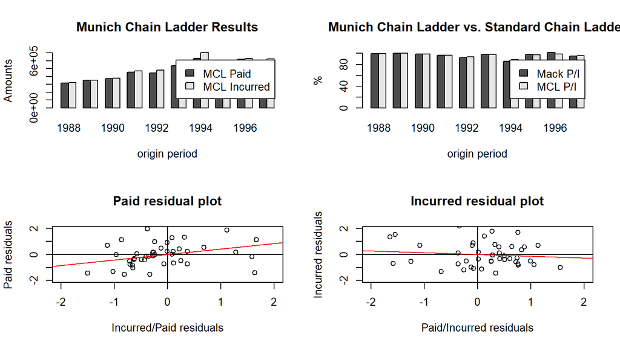

```r
plot(munich)
```

## Other methods

- Dave Clark’s methods
  - `ClarkLDF`
  - `ClarkCapeCod`
- Other stochastic methods include …
  - `BootChainLadder`: Bootstrapping
  - `tweedieReserve`: glm including one-year risk horizon (Solvency II)
  - `glmReserve`
  - `MultiChainLadder` and `MultiChainLadder2`